# Is Xtreme Gradient Boosting immune to multicollinearity?

Sebastian Cabrera, Kristen Allen, Kamel Yousri Amrouche

# Abstract

The purpose of this report is to introduce the main results and insights found after investigating the effects of multicollinearity on different supervised learning methods. More specifically, we focused our attention on analyzing conventional performance metrics for extreme gradient boosting, classification trees, and logistic regression under different assumptions. We found the performance of the extreme gradient boosting doesn’t decrease under increasing levels of multicollinearity, compared to logistic regression in which we found a significant decrease in performance. For example, increasing the number of correlated variables, from 10 to 300 meant a decrease the average area under the curve of 0.79 to 0.63 for Logistic Regression while under the same data the extreme gradient boosting performance changes from 0.750 to 0.7598.

# 1. Introduction

On a daily basis, classification models are used to support decision making, as they allow analysts to identify patterns and categorize data into different groups based on a specific set of features. The most commonly used models are Logistic regression, Decision trees, Random forest, Support vector machine, K nearest neighbor and different types of boosting. Among these methods, we highlight Xtreme Gradient Boosting, a method that outperforms traditional statistical methods, such as logistic regression, in diverse fields that range from medical to banking applications $^{1}$$^{2}$$^{3}$ . One of the reasons why it is thought that the performance of the model exceeds the performance of traditional methods, is robustness to multicollinearity. Motivated by this common assumption, in this project, we will focus our attention on testing the performance of the Extreme Gradient Boosting algorithm against 2 traditional methods commonly used, Logistic Regression and Classification trees. The remainder of this article is organized as follows. Section 2 presents related work that has been done to test multicollinearity on machine learning models. Section 3 presents the steps we used to prepare the data, and the experiments design. Section 4 describes statistics and insights found in the experiments. Finally, Section 5 concludes the research paper and outlines directions for future work.

# 2. Related work

In this section, we were interested in reviewing existing literature to see how correlated variables influence the models we selected. As the main question focus on assesing the performance of the Extreme Gradient Boosting algorithm against 2 traditional methods commonly used Logistic Regression and Classification trees ybder increasing levels of multicollinearity, we researched papers, that studied the effects of multicollinearity on these machine learning models.

A paper titled “A study of Effects of MultiCollinearity in the Multivariable Analysis”$^{4}$ found that regression model performance is not stable when the correlation coefficient of correlated variables increases. In this study, datasets were generated containing 2 correlated variables and 1 variable that was not correlated. Correlation coefficients were set ranging from -1 to 1 in increments of 0.05. The authors found that as the absolute value of the correlation coefficient increased, the regression coefficient for the correlated variables increase and their confidence intervals increase. When the correlation coefficient was set to around 0.9 or -0.9 the regression coefficient began a steep increase, from 3.8 and -1.4 respectively, to 29.7 and -27.4 when the correlation coefficient was set to 1 and -1. Implementing a regression model with correlation coefficients between variables in the range of 0.9 to 1 would cause any small change in the correlated variable to have a large effect on the prediction that was disproportionate to the actual level of correlation. As a result, the regression model errors would increase dramatically with this level of correlation.

It is postulated that Extreme gradient boosting is immune to the effects of variable collinearity. An article titled “Correlation in XGBoost” explores this question$^{5}$. The author begins with a dataset of 30 features with no correlated variables and incrementally adds variables with levels of correlation between 0.8 and 1. First, 1 variable was added which was perfectly correlated with the most important variable. This addition had no effect on the model performance or variable importance. Next, 4 variables were added with a correlation in the range of 0.97 to 0.98 to the top 4 most important original variables. This had the effect of changing the variable importance. However, there was only a minimal change in the AUC. The findings of this experiment are consistent with the theory that XGBoost performance maintains its performance with the presence of multicollinearity in the dataset. In our simulation reported below, we performed a similar test using different parameters to demonstrate how XGBoost can outperform other models like regression on datasets with collinearity.

# 3. Experiments design

In this section, we present the process used to generate the data, and train the machine learning models. For completeness, Section 3.1 describes the data generation process. Section 3.2 defines the set of parameters tested via a Montecarlo simulation. Finally, Section 3.3 describes the training procedure for the extreme gradient boosting and the other machine learning models considered in the paper.

## 3.1. Dataset generation

To generate the data, we follow a specific procedure. Firstly, we generate $X_n$ number of correlated features, each of size $S$, with the degree of correlation determined by the parameter Corr_degree. Simultaneously, we generate $Z_n$ number of uncorrelated features, also of size $S$, with a correlated degree ranging from 0 to 0.1, following a uniform random distribution. Next, the target variable $Y$ is created as the normalized sum of $X_1$ and $Z_1$. If this sum exceeds 0.5, we assign the label 1; otherwise, it is marked as 0. To ensure the target variable $Y$ is not solely determined by specific features during model training, we remove $X_1$ and $Z_1$ from the dataset after creating $Y$. Figure 1 shows the process used to generate the data.

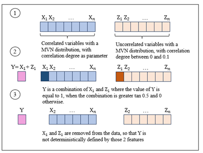

Dataset Generation process

This function to generate the data takes as parameters the seed, the number of correlated features, the number of uncorrelated features, the sample size, and the correlation degree. Take for example the generated data for seed 1234, with 2 correlated features and 2 uncorrelated features, the correlation degree for the correlated features was set to 0.9.

Example of generated data:

| Target | Correlated_1 | Correlated_2 | Noise_1 | Noise_2 |
| --- | --- | --- | --- | --- |
| 1 | -1.04 | -1.25 | 1.00 | 1.22 |
| 1 | 0.52 | 0.27 | 1.89 | 0.78 |
| 1 | 1.24 | 1.06 | -0.53 | -1.14 |
| 0 | -2.27 | -2.37 | 0.94 | -0.58 |
| 1 | 0.15 | 0.68 | 0.60 | -1.79 |
| 1 | 0.49 | 0.81 | -0.41 | -2.14 |

The cor function displays the Pearson correlation coefficient between 2 variables. It reveals that the linear correlation between the correlated variables is greater than 0.9, which is highly correlated, while the correlation between the uncorrelated variables is 0.37, closer to 0, indicating low correlation.

Correlation for generated data:

|  | Target | Correlated_1 | Correlated_2 | Noise_1 | Noise_2 |
| --- | --- | --- | --- | --- | --- |
| Target | 1.00 | 0.40 | 0.61 | -0.21 | -0.28 |
| Correlated_1 | 0.40 | 1.00 | 0.90 | -0.05 | -0.30 |
| Correlated_2 | 0.61 | 0.90 | 1.00 | -0.31 | -0.45 |
| Noise_1 | -0.21 | -0.05 | -0.31 | 1.00 | 0.37 |
| Noise_2 | -0.28 | -0.30 | -0.45 | 0.37 | 1.00 |

## 3.2. Parameters to test

As mentioned in the introduction, the objective of the project is to test the performance of the Xtreme Gradient Boosting algorithm against traditional methods, while using data with different levels of multicollinearity. To generate the data with different levels of multicollinearity we considered 5 different parameters. The set of parameters that were used to assess the research question are the following:

$\text{1. Correlation degree: degree of correlation between the correlated features } X_n$

$\text{2. } X_n: \text{number of correlated features }$

$\text{3. } Z_n: \text{number of uncorrelated features }$

$\text{4. } \text{S: data size, ex. 1000 will return 1000 rows data points for each variable }$

$\text{5. } \text{Seed: random seed to generate the data using multivariate normal distributions }$

1. Increasing the $correlation$ $degree$, will induce an increase in the level of multicollinearity of the data, and thus we will be able to test if the performance of the Xgboost model increases/decreases/remains unchanged, and also compare against the traditional methods. We will assess 5 different levels of correlation: 0.05, 0.3, 0.5, 0.7 and 0.9
2. We also investigated the effect of increasing the number of correlated variables $X_n$, by changing the number of correlated features in 5 different levels: 10, 50, 100, 200 and 300
3. Moreover we changed the uncorrelated variables $Z_n$, to assess if throwing noise variables to the model has an effect on the performance of the models under different levels of multicollinearity. We tested 10 and 50 uncorrelated variables.
4. We only used 1000 as the sample size $S$, mainly to reduce the run time while still considering a large number of data points that allow us to make meaningful conclusions
5. Changing the $Seed$, allows to test the same parameters many times, and thus examine the variability of the results under many tries, following the Montecarlo Simulation principle. We changed the seed 501 times from 1.000 till 1.500

With the parameters mentioned in the above points, we tested a total of 50 different set of parameters, 500 times for each combination, with data sets of 1000 records. 3 models were run on the generated data set (extreme gradient boosting, classification tree and logistic regression), calculating 12 performance metrics in each run. The data set has a final length of 901.800 rows:

$Seeds * Corrdegree * S * Z_n * X_n * 3 * 12 = 501 * 5 * 1 * 2 * 5 * 3 * 12 = 901.800$.

Tested parameters:

| Parameters | Tested values |
| --- | --- |
| Seed | seq(1000,1500) |
| Correlated variables | c(10,50,100,200,300) |
| Uncorrelated variables | c(10,50) |
| Size varibles | c(1000) |
| Correlation degree | c(0.05,0.3,0.5,0.7,0.9) |

## 3.3. Machine learning models coding

In our data analysis and modeling approach, we chose to utilize a combination of Extreme Gradient Boosting, logistic regression, and classification tree models, each offering unique strengths suited for diverse datasets. The primary focus of our study is on Extreme Gradient Boosting, aimed at addressing the research question concerning its immunity to multicollinearity. To establish a solid baseline, we also employed logistic regression, a widely used classification model, enabling us to compare performance metrics and trends. This comparison proves to be invaluable, especially when evaluating Extreme Gradient Boosting predictive capabilities in the presence of multicollinearity, compared to other commonly used models. By incorporating Extreme Gradient Boosting, Logistic Regression, and Classification trees into our analysis, we conducted a thorough examination of our data. Leveraging the strengths of each model, we gained valuable insights, enabling us to make more confident and nuanced conclusions regarding the research question.

### 3.3.1 Extreme Gradient Boosting

The extreme gradient boosting model that we train takes the data generated in **3.1** and uses the following set of parameters to find the best model that fits the training data (80% of the data set). The parameters used are max depth = 10, number of rounds = 25, and error as the evaluation metric. Then after training the model, it applies the model to the remaining unseen 20% of the data frame, and calculates the following metrics: Area under the curve AUC, precision, recall, sensitivity, specificity and f1. The results are saved on a list, so that they are accessible after applying the function.

The coded xgb function receives as parameters the necessary inputs to generate the data and returns the list of performance metrics on the training set. For example using seed 1234, 20 correlated variables, 10 uncorrelated variables, sample size 1000 and correlation degree for the correlated variables 0.8.

As performance metrics, we have the AUC, precision, recall, f1, sensitivity, and specificity. Since this model outputs the probabilities of each record being classified as positive, and to calculate our performance metrics a binary classification is required, we converted the probabilities given by the model to binary and calculated the performance metrics for 2 different thresholds of probability. For the first threshold, if the probability of records being classified as positive was >=50%, then it was classified as positive, else negative. For the second threshold, if the probability of records being classified as positive was >=90%, then it was classified as positive, else negative.

Example of applying the XGB function:

| Threshold | AUC | Precision | Recall | F1 | Sensitivity | Specificity |
| --- | --- | --- | --- | --- | --- | --- |
| 50% | 0.76 | 0.64 | 0.48 | 0.55 | 0.48 | 0.86 |
| 90% | 0.76 | 0.87 | 0.19 | 0.32 | 0.19 | 0.98 |

### 3.3.2 Logistic Regression

The Logistic regression model that we train takes the data generated in **3.1** and uses the following set of parameters to find the best model that fits the training data (80% of the data set). Used logit as the link function. Then after training the model, it applies the model to the remaining unseen 20% of the data frame, and calculates the following metrics: Area under the curve AUC, precision, recall, sensitivity, specificity and f1. The results are saved on a list, so that they are accessible after applying the function.

The coded logistic regression function receives as parameters, the necessary inputs to generate the data, and returns the list of performance metrics on the training set. For example using seed 1234, 20 correlated variables, 10 uncorrelated variables, sample size 1000 and correlation degree for the correlated variables 0.8.

Example of applying the Logistic Regression function:

| Threshold | AUC | Precision | Recall | F1 | Sensitivity | Specificity |
| --- | --- | --- | --- | --- | --- | --- |
| 50% | 0.76 | 0.61 | 0.42 | 0.50 | 0.42 | 0.86 |
| 90% | 0.76 | 0.71 | 0.07 | 0.14 | 0.07 | 0.98 |

### 3.3.3 Classification Tree

The Classification tree model that we train takes the data generated in **3.1** and uses the following set of parameters to find the best model that fits the training data (80% of the data set). Used method = “class”, and doesn’t put a restriction on the depth of the tree. Then after training the model, it applies the model to the remaining unseen 20% of the data frame, and calculates the following metrics: Area under the curve AUC, precision, recall, sensitivity, specificity and f1. The results are saved on a list, so that they are accessible after applying the function.

The coded classification tree function receives as parameters, the necessary inputs to generate the data, and returns the list of performance metrics on the training set. For example using seed 1234, 20 correlated variables, 10 uncorrelated variables, sample size 1000 and correlation degree for the correlated variables 0.8.

Example of applying the classification tree function:

| Threshold | AUC | Precision | Recall | F1 | Sensitivity | Specificity |
| --- | --- | --- | --- | --- | --- | --- |
| 50% | 0.68 | 0.52 | 0.36 | 0.42 | 0.36 | 0.83 |
| 90% | 0.68 | 0.79 | 0.16 | 0.27 | 0.16 | 0.98 |

# 4. Results and Insights

In this section, we present the experiments that we performed using the defined set of parameters of section 3.2. Our goal is to analyze the performance of the Extreme gradient boosting algorithm in the presence of increasing levels of multicollinearity. In addition, we describe the performance of two additional models, logistic regression and classification trees which are also commonly used in classification tasks. The experiments were performed on an Intel core i3 - 1.19 GHz with 12GB of RAM.

Due to the amount of parameters to be tested, and the 500 replicates for each set of parameters, we saved each run on .txt files inside the folders Results_lr/, Results_tree/ and Results_xgb/ and once is finished, we load all the .txt files and merge them in just one data set Induced by this procedure we were able to test 50 combinations of parameters, 500 times for each of the 3 machine learning models.

For completeness, Section 4.1 describes the results and insights for the Extreme gradient boosting algorithm. Section 4.2 presents the results for Logistic regression. Section 4.3 discusses the results for the classification tree. Finally, Section 4.4 compares the model’s performance, and presents insights from the simulation results

It was found that increasing the number of non correlated features from 10 to 50 had minimal impact on the performance of the models so no further analysis will be conducted on this variable. When the threshold of what is classified as a positive case by the model is set to 0.5, the f1, precision, recall, sensitivity, and specificity all sit at an average close to 0.6. When the threshold of what is classified as a positive case is raised to 0.9, then these metrics have a higher deviation. The precision remains near 0.6, f1, recall, and sensitivity, all drop to an average of approximately 0.2, and the specificity raises to an average of approximately 0.9. In choosing the threshold, the business context should be considered in order to identify which metrics should be prioritized.

## 4.1 Xgboost

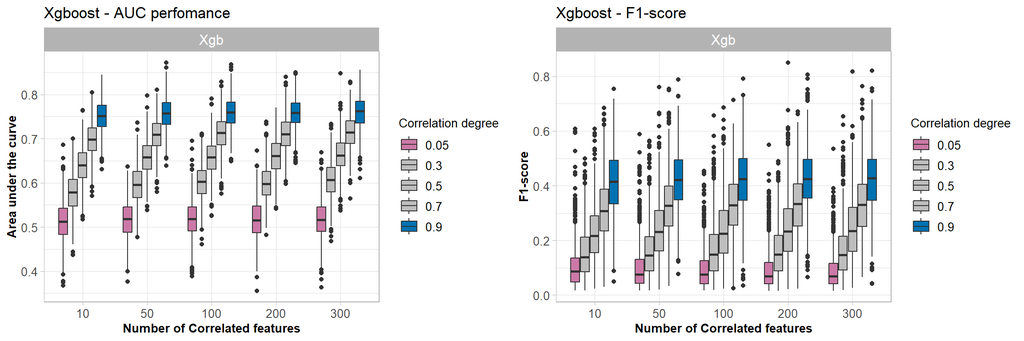

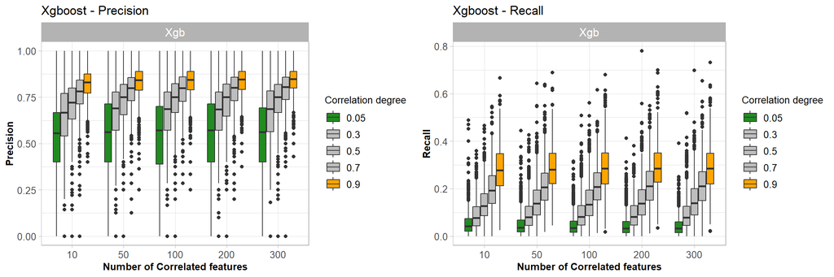

## 4.2 Logistic Regression

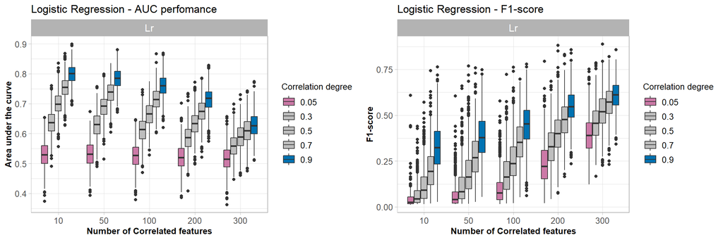

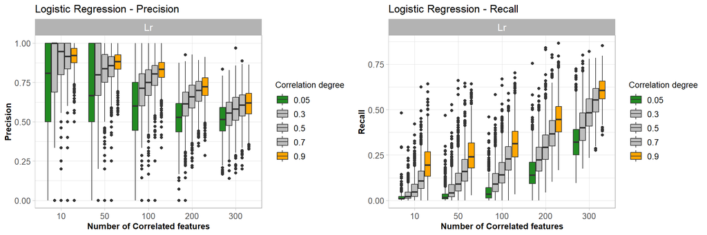

## 4.3 Tree

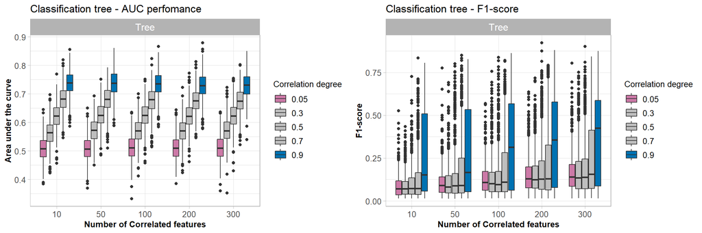

## 4.4 Model Comparison

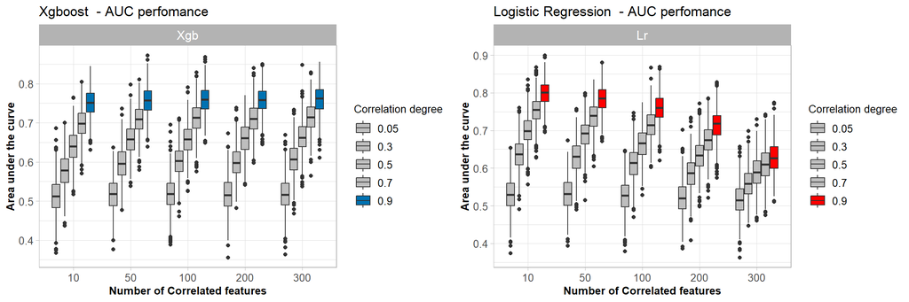

On the other hand, while investigating the f1-score which is other commonly used metric, we found that the best performing model under a 0.9 threshold is the logistic regression, as we see that the performance of the model measured by the f1-score increases under a higher amount of correlated variables, while the f1-score performance of the extreme gradient boosting remains constant. Thus the decrease in the Area under the curve for the logistic regression under increasing levels of multicollinearity is tied to a higher f1-score, and recalling the results found in section *4.2*, this is tied to increasing recall values and decreasing precision values. However, it is interesting to note that for XGBoost, the behavior of the same metric doesn’t change, which supports the claim that is indeed inmune to multicollinearity.

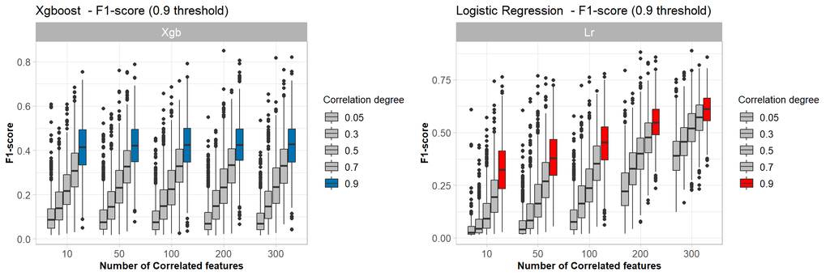

# 5. Concluding Remarks

In this brief research paper, we provided an analysis of Extreme Gradient Boosting performance under different levels of multicollinearity, and also compared the model against other commonly used supervised learning models.

In the near future, we expect to use these insights while facing decisions regarding the appropriate machine learning model to choose from in the presence of highly correlated features. We would discard logistic regression if the number of correlated variables is suspected to be high as not only inference may be affected but also performance.

# References

[1] Zhang, Z., Ho, K. M. & Hong, Y. Machine learning for the prediction of volume responsiveness in patients with oliguric acute kidney injury in critical care. Crit. Care. 23(1), 112 (2019).

[2] Chen, T. et al. Prediction and risk stratification of kidney outcomes in IgA nephropathy. Am. J. Kidney Dis. 74(3), 300–309 (2019).

[3] Hou, N. et al. Predicting 30-days mortality for MIMIC-III patients with sepsis-3: A machine learning approach using XGboost. J. Transl. Med. 18(1), 462 (2020).

[4] Wonsuk Yo. (2014) A Study of Effects of MultiCollinearity in the Multivariable Analysis.

[5] Gupta, V. (2021) Correlation in xgboost, Medium. Available at: https://vishesh-gupta.medium.com/correlation-in-xgboost-8afa649bd066 (Accessed: 10 November 2023).